# Four Basic Designs

Prof Randi Garcia  
January 5, 2021

### Reading contemplation question

1. Was this design principal of *crossing* present in Kelly's hamster experiment?

### Announcements

- Slack issues
- Registration

### Our First Experiment

Get in breakout groups of ~8 we will discuss.

As you participate in the experiment at the link below, remember:

- what you saw
- what you did
- the order in which it happened.

To participate, find the experiment link in the course schedule!! **http://bit.ly/sds290interterm21**

### Our First Experiment

In your groups:

- Take turns describing what you saw/did.
- Your objective, as a group, is to describe the FULL experimental design.

Discussion questions:

- What were all of the possibilities? How do you think that was determined?
- Which conditions were distributed *across* people, and which *within* people?
- What do you think are the possible research questions answered by this study?

### What makes a study an "Experiment"?

- Can you assign experimental material to conditions?
- You've created those conditions
- If the material alredy comes in different “varieties”, then it's an *observational* study
  - People with different psychiatric illnesses
  - Different species of plants
- Sometimes one “study” will have both **experimental** and **observational** variables

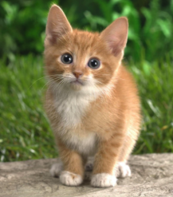

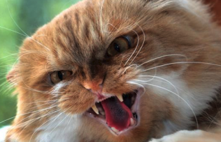

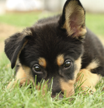

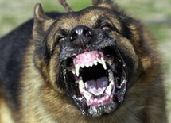

### Sources of Variability

Think about all of the reasons calmness scores may differ (vary).

1. Vary across conditions
2. Vary because of measurement error
3. Vary because of experimental material (you!) differences

### Kinds of Variability

1. Planned, systematic
2. Chance-like
3. **Unplanned, systematic**

### Unplanned, Systematic Variability

If we suspect there is unplanned, systematic variability, we should do what we can to turn it into planned, systematic, or chance-like variability

- Confounding variables
- Bias

### Confounding Variables

I want to test if smelling a tasty food (fresh cinnamon rolls) versus a non-tasty food (broccoli) has an effect on salivation in humans. So, I recruit some participants to come to my lab, I'll have to bake the cinnamon rolls and run that condition all at once, so I decide that I will bake my rolls at 9a, then from 10a-12p I will run the cinnamon roll condition. I bring people into individual distraction free rooms, hook them up to the salivation sensor, then bring them a plate with a freshly baked cinnamon roll. I record their salivation. Then, I will run the broccoli from 1p-3p, using the same measurement procedure.

Are there any confounding variables in my study?

### Bias

Our data will be “off” in a systematic, non-random, way

- Sampling Bias: Biologist is using a net with large holes to capture a sample of fish from a lake.
- Selection Bias: Assigning the skinnier rats to the good lab chow.

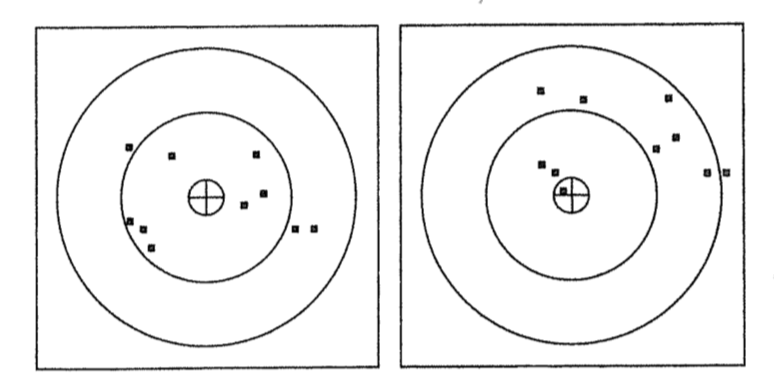

### Kelly's Hamster Study

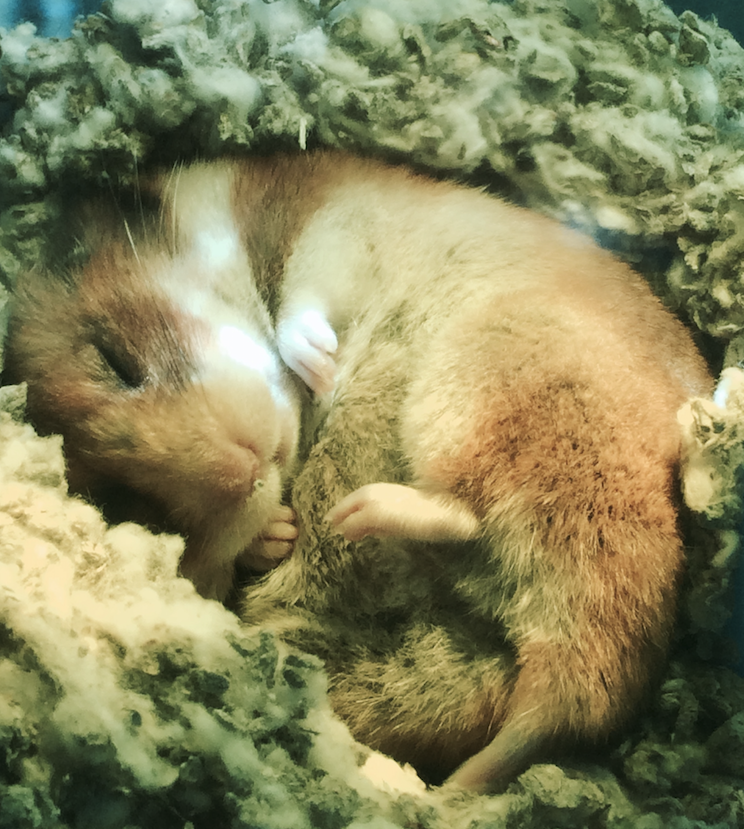

### Design Principal 1: Random Assignment

Design 1: Randomized Basic Factorial Design

- BF[1]

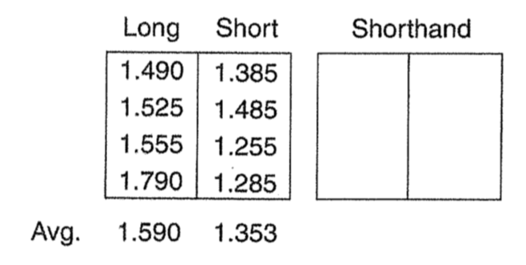

### Design Principal 2: Blocking

Design 2: One-Way Complete Block Design

- CB[1]

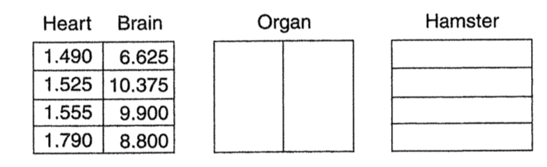

### Design Principal 3: Factorial Crossing

Design 3: Two-Way Basic Factorial Design

- BF[2]

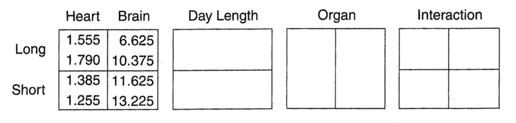

### Kelly's Hamster Study

### Blocking + Random Assignment + Crossing

Design 4: Split Plot/Repeated Measures Design

- SP/RM[1,1]

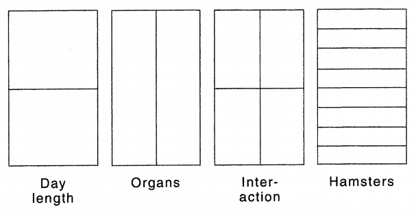

### The Meats

Randomized Basic Factorial Design BF[1]

The shelf life of meats is the time a prepackaged cut remains salable, safe, and nutritious. Recent studies suggested controlled gas atmospheres as possible alternatives to existing packaging. To test this, beef steaks (75\( g \)) were randomly assigned to packaging with either 1) ambient air in a commercial plastic wrap, 2) vacuum packed, 3) 100% carbon dioxide (\( CO_2 \)), or 4) a mixture of 1% carbon monoxide (CO), 40% oxygen (\( O_2 \)), and 59% nitrogen (N). The number of psychrotrophic bacteria on the meat was measured after nine days of storage at 4 degrees C.